# DATA 624: Group 2 Homework

Juliann McEachern

# Assignment 4

Assignment 4 includes problem 7.1 and 7.3 from the HA text. The following R packages have been used for completion of all homework assignments to date:

```r
#Textbook Packages
library(fpp2)
library(AppliedPredictiveModeling)
library(mlbench)

#Processing
library(tidyverse)

#Graphing
library(ggplot2)
library(gridExtra)

#Math
library(caret)
library(randomForest)
library(seasonal)
library(psych)
library(corrplot)

#Formatting
library(knitr)
library(kableExtra)
```

## 7.1: Consider the `pigs` series – the number of pigs slaughtered in Victoria each month.

### (a). Use the `ses()` function in R to find the optimal values of $\alpha$ and $\ell_0$, and generate forecasts for the next four months.

#### Forecast Summary

The forecast summary below shows us the optimal values of $\alpha$ and $\ell_0$, as estimated by the `ses` function in R.

```r
pigsdata <- window(pigs, start=1980)
fc <- ses(pigsdata, h=4)
summary(fc)
```

```
##
## Forecast method: Simple exponential smoothing
##
## Model Information:
## Simple exponential smoothing
##
## Call:
##  ses(y = pigsdata, h = 4)
##
##   Smoothing parameters:
##     alpha = 0.2971
##
##   Initial states:
##     l = 77260.0561
##
##   sigma:  10308.58
##
##      AIC     AICc      BIC
## 4462.955 4463.086 4472.665
##
## Error measures:
##                    ME    RMSE      MAE       MPE     MAPE      MASE
## Training set 385.8721 10253.6 7961.383 -0.922652 9.274016 0.7966249
##                    ACF1
## Training set 0.01282239
##
## Forecasts:
##          Point Forecast    Lo 80    Hi 80    Lo 95    Hi 95
## Sep 1995       98816.41 85605.43 112027.4 78611.97 119020.8
## Oct 1995       98816.41 85034.52 112598.3 77738.83 119894.0
## Nov 1995       98816.41 84486.34 113146.5 76900.46 120732.4
## Dec 1995       98816.41 83958.37 113674.4 76092.99 121539.8
```

#### Visualization

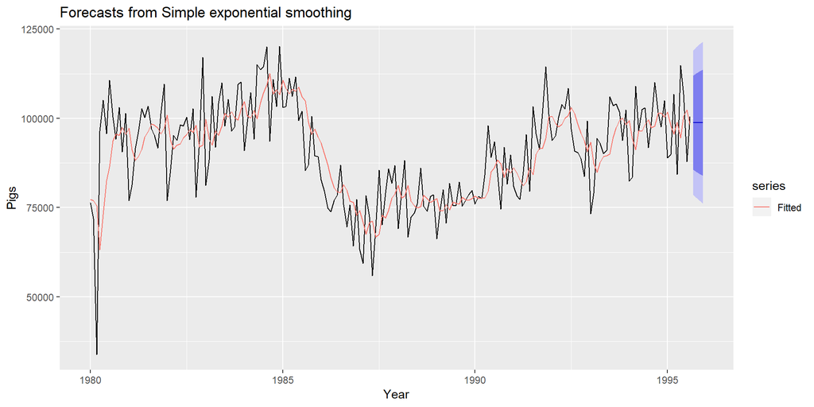

```r
autoplot(fc) +
  autolayer(fitted(fc), series="Fitted") +
  ylab("Pigs") + xlab("Year")
```

### (b). Compute a 95% prediction interval for the first forecast using $\hat{y}\pm1.96s$ where $s$ is the standard deviation of the residuals. Compare your interval with the interval produced by R.

Formula calculations of the confidence interval were obtained using $\bar{x} \pm 1.96s$ and compared to the calculations from the `ses` function in R.

```r
# Formula Calculatioin
lower <- fc$mean[1]- 1.96*sd(fc$residuals)
upper <- fc$mean[1]+ 1.96*sd(fc$residuals)

# R Calculation
lowerR <- as.numeric(fc$lower[1, "95%"])
upperR <- as.numeric(fc$upper[1, "95%"])
```

Comparison of 95% Confidence Interval Calculations

| 95% | Computed | R |
| --- | --- | --- |
| Lower | 78679.9672534162 | 78611.9684577467 |
| Upper | 118952.844969765 | 119020.843765435 |

## 7.3: Modify your function from the previous exercise to return the sum of squared errors rather than the forecast of the next observation. Then use the `optim()` function to find the optimal values of $\alpha$ and $\ell_0$. Do you get the same values as the `ses()` function?

### Function

The prior question asks us to write a function to implement simple exponential smoothing. I experienced difficulty in doing so, thus turning to [stackexchange](https://stats.stackexchange.com/questions/379727/how-to-use-optim-function-in-r-on-my-custom-residual-sum-of-squares-function) for reference. The functions below are modeled from this source

```r
# Custom SES Function
custom_ses = function(ts, alpha, l0){
  N = length(ts)
  y_hat = c(l0, 0 * (2:N))
  for (j in 1:(N-1))
    {
    new = alpha * ts[j] + (1-alpha) * y_hat[j]
    y_hat[j+1] = new
  }
  return(y_hat)
}

# SSE function
custom_sse = function(fn, ts){
  alpha <- fn[1]
  l0 <- fn[2]
  N = length(ts)
  fit = custom_ses(ts, alpha, l0)
  res = ts - fit
  out = sum(res^2)/(N-1)
  return(out)
}
```

### Optimization

```r
# `optim` Function
optimize <- optim(par = c(0.1, 10000), fn = custom_sse, ts = pigsdata)

# Optimized Parameters
alpha = optimize$par[1]
l0 = optimize$par[2]

# SES Model Parameters
ses_alpha <-fc$model$fit$par[1]
ses_l0 <-fc$model$fit$par[2]
```

The calculated differences between the R estimated paremeters and optimized paremeters from the custom function were minimal, and can be viewed below:

Comparison of Parameter Values

| SES Function | alpha | l0 |
| --- | --- | --- |
| Custom Optimized | 0.297214493242571 | 77260.9584487885 |
| R Estimated | 0.297148833372095 | 77260.0561458528 |

### Visualization

A timeseries plot of our fitted (estimated) and custom (optimized) values show vast similiarities. There difference between the two is hard to distinguish on the plot.

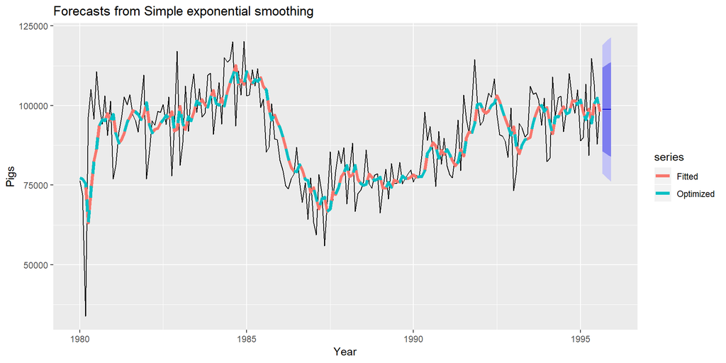

```r
fit = custom_ses(pigsdata, alpha = alpha, l0 = l0)
ts_fit <- ts(fit, start=1980, frequency = 12)

autoplot(fc) +
  autolayer(fitted(fc), series="Fitted", size=1.5) +
  autolayer(ts_fit, series="Optimized", linetype = "dashed", size=1.5) +
  ylab("Pigs") + xlab("Year")
```